# Exponential Smoothing Forecasting

## Introdution

*This is a reading summary of FPP2 chapter 7*

First proposed by Holt(1957), Brown(1959), and Winter(1960)

> weighted averages of past observations, with the weights decaying exponentially as the observations get older. In other words, the more recent the observation the higher the associated weight.

## SES(simple exponential smoothing)

*For data that has no obvious trend or season*

[defination] (https://otexts.com/fpp2/ses.html#eq:7-ses) for any a between 0 and 1, the weights attached to the observations decrease exponentially as we go back in time, hence the name “exponential smoothing”.

> The forecast at time is equal to a weighted average between the most recent observation and the previous forecast. The application of every exponential smoothing method requires the smoothing parameters (a) and the initial values (L0) to be chosen.

Smoothing parameter can be estimated base on knowlodge, or commonly by observed data, for example SSE(sum of squared errors), but non-linear we have to use optimaztion.

```r
oildata <- window(oil, start=1996)
fc<-ses(oildata, h=5)
summary(fc)
```

```
##
## Forecast method: Simple exponential smoothing
##
## Model Information:
## Simple exponential smoothing
##
## Call:
##  ses(y = oildata, h = 5)
##
##   Smoothing parameters:
##     alpha = 0.8339
##
##   Initial states:
##     l = 446.5868
##
##   sigma:  29.8282
##
##      AIC     AICc      BIC
## 178.1430 179.8573 180.8141
##
## Error measures:
##                    ME     RMSE     MAE      MPE     MAPE      MASE
## Training set 6.401975 28.12234 22.2587 1.097574 4.610635 0.9256774
##                     ACF1
## Training set -0.03377748
##
## Forecasts:
##      Point Forecast    Lo 80    Hi 80    Lo 95    Hi 95
## 2014       542.6806 504.4541 580.9070 484.2183 601.1429
## 2015       542.6806 492.9073 592.4539 466.5589 618.8023
## 2016       542.6806 483.5747 601.7864 452.2860 633.0752
## 2017       542.6806 475.5269 609.8343 439.9778 645.3834
## 2018       542.6806 468.3452 617.0159 428.9945 656.3667
```

*`ses` using `ets` to estimate `a` and `L0` by default.*, above output is same as using `ets(oildata)$fit$par`, `a` and `L0` are 0.83 and 446.

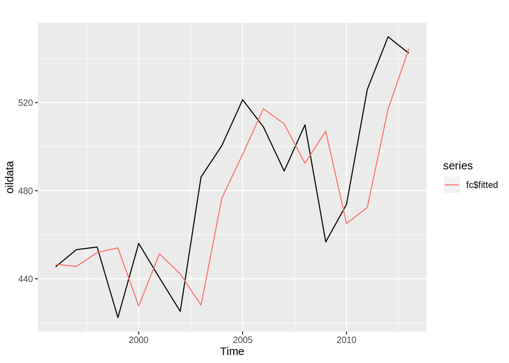

```r
autoplot(oildata) + autolayer(fc$fitted)
```

## Holt’s linear trend method

*for data with trend*, inlcude smoothing of trend, forecast = level(estimated level) + trend(estimated slope), see [defination](https://otexts.com/fpp2/holt.html)

level is same as SES, in 2nd equation, beta* is smoothing parameter(0 to 1), b(t) is previous estimated trend.

```r
air <- window(ausair, start=1990)
fc <- holt(air, h=5)
summary(fc)
```

```
##
## Forecast method: Holt's method
##
## Model Information:
## Holt's method
##
## Call:
##  holt(y = air, h = 5)
##
##   Smoothing parameters:
##     alpha = 0.8302
##     beta  = 1e-04
##
##   Initial states:
##     l = 15.5715
##     b = 2.1017
##
##   sigma:  2.3645
##
##      AIC     AICc      BIC
## 141.1291 143.9863 147.6083
##
## Error measures:
##                       ME     RMSE     MAE        MPE     MAPE      MASE
## Training set 0.008359331 2.182343 1.52892 -0.3244107 3.820787 0.6654839
##                     ACF1
## Training set -0.01335362
##
## Forecasts:
##      Point Forecast    Lo 80    Hi 80    Lo 95    Hi 95
## 2017       74.60130 71.57106 77.63154 69.96695 79.23566
## 2018       76.70304 72.76440 80.64169 70.67941 82.72668
## 2019       78.80478 74.13092 83.47864 71.65673 85.95284
## 2020       80.90652 75.59817 86.21487 72.78810 89.02494
## 2021       83.00826 77.13343 88.88310 74.02348 91.99305
```

## Damped trend method

*for data regress to flat line over time*, Holt linear increase or desrease is indefinite, Empirical evidence(based on observation or experience), it over-estimated. Dumped trend method introduced in 1985 by Gardner & McKenzie, proven very successful and arguably most popular individual method when forecasting many series automatically. It add a parameter that “dampens” trend to flat line in future. adding to Holt’s linear, is phi, between 0 and 1, if phi is 1, it’s idential to Holt’s linear method, commonly set over 0.8, and less than 0.98.

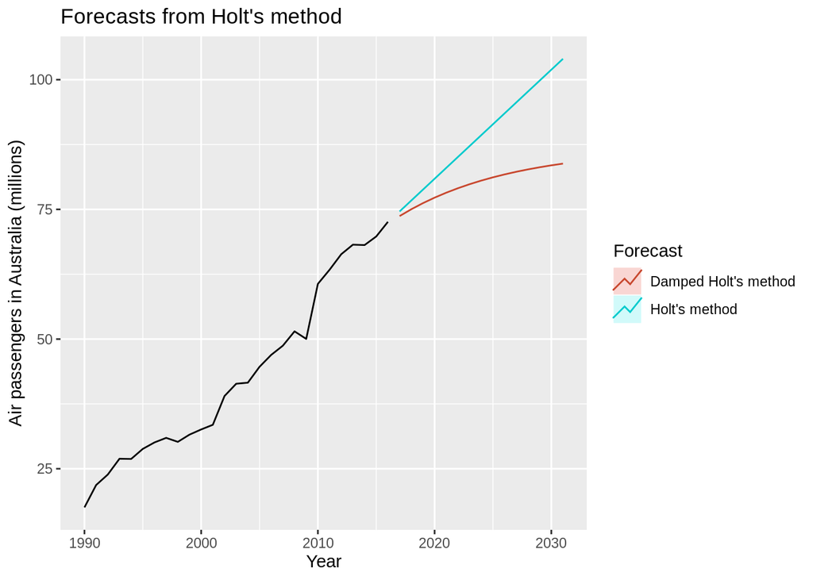

```r
fc <- holt(air, h=15)
fc2 <- holt(air, damped=TRUE, phi = 0.9, h=15)
autoplot(air) +
  autolayer(fc, series="Holt's method", PI=FALSE) +
  autolayer(fc2, series="Damped Holt's method", PI=FALSE) +
  ggtitle("Forecasts from Holt's method") + xlab("Year") +
  ylab("Air passengers in Australia (millions)") +
  guides(colour=guide_legend(title="Forecast"))
```

## Holt-Winter seasonal method

*for data with trend and seasonality*

added seasonal smoothing parameter gamma. `s(t) = gamma* x (y(t)-iota(t)) + (1- gamma*) x s(t-m)`, where m is integer of seasons, 4 for quarterly, 12 for monthly etc. equation see (https://otexts.com/fpp2/holt-winters.html)

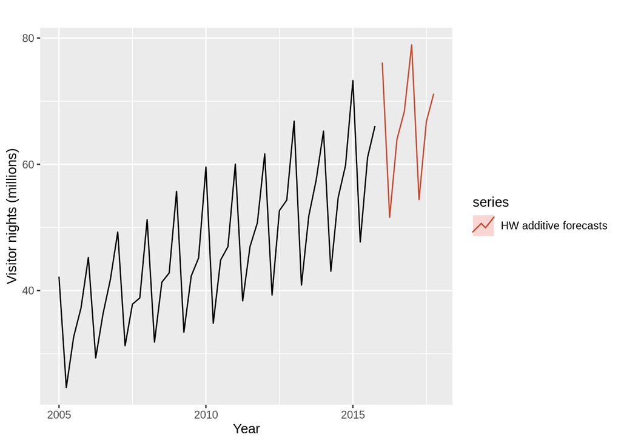

```r
aust <- window(austourists,start=2005)
fit1 <- hw(aust,seasonal="additive")
autoplot(aust) +
  autolayer(fit1, series="HW additive forecasts", PI=FALSE) +
  xlab("Year") +
  ylab("Visitor nights (millions)")
```

*removed multiplicative, since season variation is roughly consistent.*

*damping* is possible to seasonal holt-winter both additive and multiplicative., juset set `damped=TRUE` in `hw` function.

## Estimation of models

using nformation criteria for model selection.

*CV (cross validation)*

1,remove one observation and fit model with remaining data, the you got error, 2, repeat for all observed data, 3, then compute MSE from all errors.

*AIC (Akaike’s information criterion)*

`AIC=T * log(SSE/T) + 2(k+2)`, T is number of observation used for estimation, k is number of predictor in model. good for small number of T

*AICc, corrected AIC*

`AICc=AIC + (2(k+2)(k+3)/(T-k-3))` correct bias

*BIC(Bayesian information criterion)*

`BIC=T * log(SSE/T) + (k+2) * log(T)`, BIC penalize number of parameter heavily compares to AIC

*stepwise regression:* not part of forecasting modeling but part of regression concept.

when there are too manyu predictors, 1, start with all predictors, 2, remove one and measure accurary, 3 repeat removall. “forward stepwise regression” when toooo many predicotrs, start with intercept, then add predictor one by one, measure if imporve accuracy.

## forecasting with ETS models

Forecasted data is t > T(last obsvered) with error is zero.

*prediction interval* cab be complicated, for additive errors, see (https://otexts.com/fpp2/ets-forecasting.html#tab:pitable), in those equations, delta sqared is residual variances ie (sum(x^2)/(n-2)) where x is residual(observed - predicted), m is seasonal period.

```r
fit <- ets(window(austourists, start= 2005))
summary(fit)
```

```
## ETS(M,A,M)
##
## Call:
##  ets(y = window(austourists, start = 2005))
##
##   Smoothing parameters:
##     alpha = 0.1908
##     beta  = 0.0392
##     gamma = 2e-04
##
##   Initial states:
##     l = 32.3679
##     b = 0.9281
##     s = 1.0218 0.9628 0.7683 1.2471
##
##   sigma:  0.0383
##
##      AIC     AICc      BIC
## 224.8628 230.1569 240.9205
##
## Training set error measures:
##                      ME     RMSE     MAE        MPE     MAPE     MASE
## Training set 0.04836907 1.670893 1.24954 -0.1845609 2.692849 0.409454
##                   ACF1
## Training set 0.2005962
```

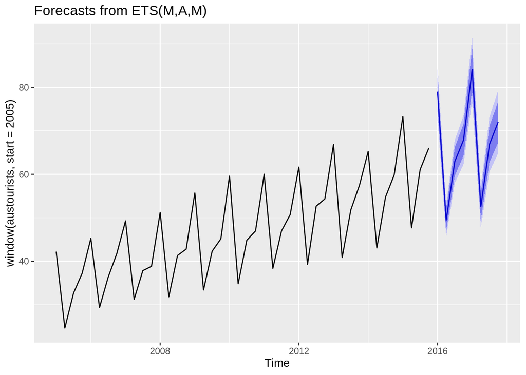

```r
fit %>% forecast(h=8) %>% autoplot()
```

## Appendix

### state space, `?ets`

- The first letter denotes the error type (“A”, “M” or “Z”);
- the second letter denotes the trend type (“N”,”A”,”M” or “Z”);
- the third letter denotes the season type (“N”,”A”,”M” or “Z”).

“N”=none, “A”=additive, “M”=multiplicative and “Z”=automatically selected.

for example,

- “ETS(A,N,N)”: simple exponential smoothing with additive errors,
- “ETS(M,N,N)”: simple exponential smoothing with multiplicative errors
- “ETS(M,A,M)”: multiplicative Holt-Winters’ method with multiplicative errors, and so on.
- “ETS(M,A,N)”: holt linear with multiplicative errors
- “ETS(A,A,N)”: holt linear with additive errors

### logistic function, https://en.wikipedia.org/wiki/Logistic_function

- x0 = the x-value of the sigmoid’s midpoint,
- L = the curve’s maximum value, and
- k = the logistic growth rate or steepness of the curve.[1]

```r
# x input, a sequence for demo
logistic <- function(L,k,x,x0) {
  L / (1 + exp( -1 * k * (x -x0)))}
```